# Homework 3

*Keke Wu*

```python
import numpy as np
import scipy.stats as st
import pandas as pd
import matplotlib.pyplot as plt
```

# Working with distributions

## Loading the data

Note that I am only keeping a few of the many columns that are present in the data. Note this step takes a long time because you are downloading a pretty large file over the Internet and decompressing it. You can download this file in your browser and access it locally to avoid needing the heavy bandwidth each time you run this file.

```python
keep_cols = ['CASE_NUMBER', 'CASE_STATUS', 'CASE_SUBMITTED',
       'JOB_TITLE', 'SOC_CODE', 'SOC_NAME', 'NAICS_CODE', 'TOTAL_WORKERS',
       'NEW_EMPLOYMENT', 'CONTINUED_EMPLOYMENT', 'CHANGE_PREVIOUS_EMPLOYMENT',
       'NEW_CONCURRENT_EMP', 'CHANGE_EMPLOYER', 'AMENDED_PETITION',
       'FULL_TIME_POSITION', 'PREVAILING_WAGE',
       'WAGE_RATE_OF_PAY_FROM', 'WAGE_RATE_OF_PAY_TO', 'WAGE_UNIT_OF_PAY']

url = 'http://rodan.cdm.depaul.edu/~rburke/courses/h1b-2018.zip'

h1b = pd.read_csv(url, usecols=keep_cols, thousands=',', compression='zip')
print (h1b.shape)
h1b.head()
```

```
(654360, 19)
```

|  | CASE_NUMBER | CASE_STATUS | CASE_SUBMITTED | JOB_TITLE | SOC_CODE | SOC_NAME | NAICS_CODE | TOTAL_WORKERS | NEW_EMPLOYMENT | CONTINUED_EMPLOYMENT | CHANGE_PREVIOUS_EMPLOYMENT | NEW_CONCURRENT_EMP | CHANGE_EMPLOYER | AMENDED_PETITION | FULL_TIME_POSITION | PREVAILING_WAGE | WAGE_RATE_OF_PAY_FROM | WAGE_RATE_OF_PAY_TO | WAGE_UNIT_OF_PAY |
| --- | --- | --- | --- | --- | --- | --- | --- | --- | --- | --- | --- | --- | --- | --- | --- | --- | --- | --- | --- |
| 0 | I-200-18026-338377 | CERTIFIED | 1/29/18 | SOFTWARE ENGINEER | 15-1132 | SOFTWARE DEVELOPERS, APPLICATIONS | 51121.0 | 1 | 0 | 1 | 0 | 0 | 0 | 0 | Y | 112549.0 | 143915.0 | 0.0 | Year |
| 1 | I-200-17296-353451 | CERTIFIED | 10/23/17 | TAX SENIOR | 13-2011 | ACCOUNTANTS AND AUDITORS | 541211.0 | 1 | 0 | 0 | 0 | 0 | 1 | 0 | Y | 79976.0 | 100000.0 | 0.0 | Year |
| 2 | I-200-18242-524477 | CERTIFIED | 8/30/18 | DATABASE ADMINISTRATOR | 15-1141 | DATABASE ADMINISTRATORS | 541511.0 | 1 | 0 | 0 | 0 | 0 | 1 | 0 | Y | 77792.0 | 78240.0 | 0.0 | Year |
| 3 | I-200-18070-575236 | CERTIFIED | NaN | SOFTWARE ENGINEER | 15-1132 | SOFTWARE DEVELOPERS, APPLICATIONS | 541511.0 | 5 | 5 | 0 | 0 | 0 | 0 | 0 | Y | 84406.0 | 84406.0 | 85000.0 | Year |
| 4 | I-200-18243-850522 | CERTIFIED | 8/31/18 | MICROSOFT DYNAMICS CRM APPLICATION DEVELOPER | 15-1132 | SOFTWARE DEVELOPERS, APPLICATIONS | 541511.0 | 1 | 0 | 0 | 0 | 0 | 0 | 1 | Y | 87714.0 | 95000.0 | 0.0 | Year |

## [TODO] Extract jobs occupation code for academics in math and science

We also want to make sure that we are looking only at full-time positions and for a full-year. Otherwise, the salary information will be harder to compare.

- professors in math and science areas SOC_CODE = 25-1022
- WAGE_UNIT_OF_PAY = Year
- FULL_TIME_POSITION = Y

Use binary indexing and conjoin the different clauses with & (and): each record must satisfy all the criteria.

Print the shape and show the `head()` of the data frame. You should have 775 rows.

```python
professors_in_math_science = h1b[(h1b.SOC_CODE=='25-1022') & (h1b.WAGE_UNIT_OF_PAY=='Year') & (h1b.FULL_TIME_POSITION=='Y')]
print(professors_in_math_science.shape)
professors_in_math_science.head()
```

```
(775, 19)
```

|  | CASE_NUMBER | CASE_STATUS | CASE_SUBMITTED | JOB_TITLE | SOC_CODE | SOC_NAME | NAICS_CODE | TOTAL_WORKERS | NEW_EMPLOYMENT | CONTINUED_EMPLOYMENT | CHANGE_PREVIOUS_EMPLOYMENT | NEW_CONCURRENT_EMP | CHANGE_EMPLOYER | AMENDED_PETITION | FULL_TIME_POSITION | PREVAILING_WAGE | WAGE_RATE_OF_PAY_FROM | WAGE_RATE_OF_PAY_TO | WAGE_UNIT_OF_PAY |
| --- | --- | --- | --- | --- | --- | --- | --- | --- | --- | --- | --- | --- | --- | --- | --- | --- | --- | --- | --- |
| 66 | I-200-16054-038551 | CERTIFIED-WITHDRAWN | 2/23/16 | J.L. DOOB RESEARCH ASSISTANT PROFESSOR | 25-1022 | MATHEMATICAL SCIENCE TEACHERS, POSTSECONDARY | 611310.0 | 1 | 1 | 0 | 0 | 0 | 0 | 0 | Y | 38260.0 | 52000.0 | 0.0 | Year |
| 363 | I-200-18059-096740 | DENIED | 2/28/18 | ASSISTANT PROFESSOR | 25-1022 | MATHEMATICAL SCIENCE TEACHERS, POSTSECONDARY | 611310.0 | 1 | 0 | 1 | 0 | 0 | 0 | 0 | Y | 33070.0 | 80000.0 | 0.0 | Year |
| 973 | I-200-18040-127892 | CERTIFIED-WITHDRAWN | 2/15/18 | ASSISTANT PROFESSOR | 25-1022 | MATHEMATICAL SCIENCE TEACHERS, POSTSECONDARY | 611310.0 | 1 | 0 | 1 | 0 | 0 | 0 | 0 | Y | 50680.0 | 88115.0 | 0.0 | Year |
| 2040 | I-200-17340-332208 | CERTIFIED | 12/6/17 | ASSISTANT PROFESSOR | 25-1022 | MATHEMATICAL SCIENCE TEACHERS, POSTSECONDARY | 611310.0 | 1 | 1 | 0 | 0 | 0 | 0 | 0 | Y | 37530.0 | 62500.0 | 0.0 | Year |
| 2544 | I-200-18128-129134 | CERTIFIED | 5/8/18 | LECTURER | 25-1022 | MATHEMATICAL SCIENCE TEACHERS, POSTSECONDARY | 611310.0 | 1 | 0 | 1 | 0 | 0 | 0 | 0 | Y | 48210.0 | 48577.0 | 0.0 | Year |

### [TODO] Create a boxplot of WAGE_RATE_OF_PAY_FROM

This is the amount the company is proposing to pay the prospective H1B visa holder.

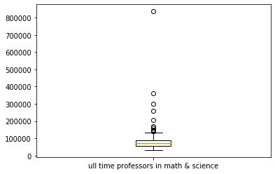

```python
plt.boxplot([professors_in_math_science.WAGE_RATE_OF_PAY_FROM], labels=["ull time professors in math & science"]);
```

### [TODO] Outlier

There is a major outlier in this data. Using `idxmax` print this row of the data.

```python
outlier_idx = professors_in_math_science.WAGE_RATE_OF_PAY_FROM.idxmax()
outlier_idx
print(professors_in_math_science.loc[outlier_idx])
```

```
CASE_NUMBER                                             I-200-18110-490090
CASE_STATUS                                                      WITHDRAWN
CASE_SUBMITTED                                                     4/20/18
JOB_TITLE                                              ASSISTANT PROFESSOR
SOC_CODE                                                           25-1022
SOC_NAME                      MATHEMATICAL SCIENCE TEACHERS, POSTSECONDARY
NAICS_CODE                                                          611310
TOTAL_WORKERS                                                            1
NEW_EMPLOYMENT                                                           1
CONTINUED_EMPLOYMENT                                                     0
CHANGE_PREVIOUS_EMPLOYMENT                                               0
NEW_CONCURRENT_EMP                                                       0
CHANGE_EMPLOYER                                                          0
AMENDED_PETITION                                                         0
FULL_TIME_POSITION                                                       Y
PREVAILING_WAGE                                                      83640
WAGE_RATE_OF_PAY_FROM                                               836400
WAGE_RATE_OF_PAY_TO                                                      0
WAGE_UNIT_OF_PAY                                                      Year
Name: 467790, dtype: object
```

### [TODO] What is the problem here? (Compare prevailing wage and wage rate from values.)

Answer: The prevailing wage is about tenth of the wage rate, which is unusual and might just be a typo.

## [TODO] Clean up the data to remove this entry

```python
cl_professors = professors_in_math_science.drop(index=outlier_idx)
print(cl_professors.shape)
```

```
(774, 19)
```

```python
cl_professors.WAGE_RATE_OF_PAY_FROM.describe()
```

```
count       774.000000
mean      75448.039806
std       26467.341097
min       31890.000000
25%       57321.000000
50%       72000.000000
75%       89218.500000
max      360000.000000
Name: WAGE_RATE_OF_PAY_FROM, dtype: float64
```

## Wage distribution

[TODO] Compute a histogram of the wage distribution. Use bins of size $10,000

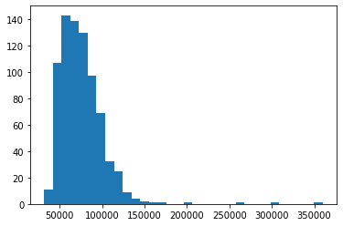

```python
bin_wage = int((cl_professors.WAGE_RATE_OF_PAY_FROM.max() - cl_professors.WAGE_RATE_OF_PAY_FROM.min())/10000)
plt.hist(cl_professors.WAGE_RATE_OF_PAY_FROM, bins=bin_wage);
```

[TODO] Compute the normal probability plot

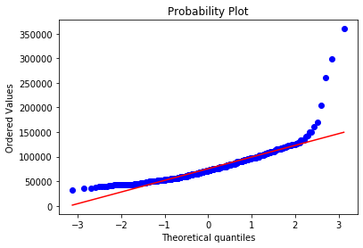

```python
st.probplot(cl_professors.WAGE_RATE_OF_PAY_FROM, dist='norm', plot = plt);
```

### [TODO] Interpret

What can we learn about the "normality" of the wage distribution?

## Assistant professors

[TODO] Extract the assistant professors from the data set, so that the distribution does not combine junior and senior faculty salaries.

NEW

Hint: Use `.str.contains('ASSISTANT PROF')` as the boolean indexer to extract the appropriate rows.

```python
assistant_professors = cl_professors[(cl_professors.JOB_TITLE.str.contains('ASSISTANT PROF'))]
assistant_professors.head()
```

|  | CASE_NUMBER | CASE_STATUS | CASE_SUBMITTED | JOB_TITLE | SOC_CODE | SOC_NAME | NAICS_CODE | TOTAL_WORKERS | NEW_EMPLOYMENT | CONTINUED_EMPLOYMENT | CHANGE_PREVIOUS_EMPLOYMENT | NEW_CONCURRENT_EMP | CHANGE_EMPLOYER | AMENDED_PETITION | FULL_TIME_POSITION | PREVAILING_WAGE | WAGE_RATE_OF_PAY_FROM | WAGE_RATE_OF_PAY_TO | WAGE_UNIT_OF_PAY |
| --- | --- | --- | --- | --- | --- | --- | --- | --- | --- | --- | --- | --- | --- | --- | --- | --- | --- | --- | --- |
| 66 | I-200-16054-038551 | CERTIFIED-WITHDRAWN | 2/23/16 | J.L. DOOB RESEARCH ASSISTANT PROFESSOR | 25-1022 | MATHEMATICAL SCIENCE TEACHERS, POSTSECONDARY | 611310.0 | 1 | 1 | 0 | 0 | 0 | 0 | 0 | Y | 38260.0 | 52000.0 | 0.0 | Year |
| 363 | I-200-18059-096740 | DENIED | 2/28/18 | ASSISTANT PROFESSOR | 25-1022 | MATHEMATICAL SCIENCE TEACHERS, POSTSECONDARY | 611310.0 | 1 | 0 | 1 | 0 | 0 | 0 | 0 | Y | 33070.0 | 80000.0 | 0.0 | Year |
| 973 | I-200-18040-127892 | CERTIFIED-WITHDRAWN | 2/15/18 | ASSISTANT PROFESSOR | 25-1022 | MATHEMATICAL SCIENCE TEACHERS, POSTSECONDARY | 611310.0 | 1 | 0 | 1 | 0 | 0 | 0 | 0 | Y | 50680.0 | 88115.0 | 0.0 | Year |
| 2040 | I-200-17340-332208 | CERTIFIED | 12/6/17 | ASSISTANT PROFESSOR | 25-1022 | MATHEMATICAL SCIENCE TEACHERS, POSTSECONDARY | 611310.0 | 1 | 1 | 0 | 0 | 0 | 0 | 0 | Y | 37530.0 | 62500.0 | 0.0 | Year |
| 3947 | I-200-18066-520644 | CERTIFIED | 3/13/18 | VISITING ASSISTANT PROFESSOR | 25-1022 | MATHEMATICAL SCIENCE TEACHERS, POSTSECONDARY | 611310.0 | 1 | 1 | 0 | 0 | 0 | 0 | 0 | Y | 43580.0 | 66000.0 | 0.0 | Year |

### [TODO] Histogram and [TODO] normal probability plot as above

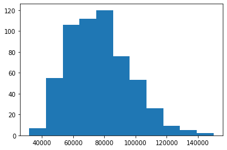

```python
wage_bins = int((assistant_professors.WAGE_RATE_OF_PAY_FROM.max() - assistant_professors.WAGE_RATE_OF_PAY_FROM.min())/10000)
plt.hist(assistant_professors.WAGE_RATE_OF_PAY_FROM, bins=wage_bins);
```

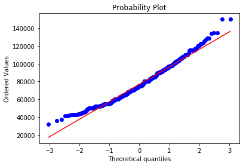

```python
st.probplot(assistant_professors.WAGE_RATE_OF_PAY_FROM, dist='norm', plot = plt);
```

### [TODO] Interpret

Is this closer to a normal distribution? What deviations remain?

### Comparison

Using the random value simulation technique from the in-class exercise, create a plot of the density-based histogram and the theoretical curve. Use 10,000 simulated values. It should look something like this:

[figure not shown]

Steps:

- Create random variable
- Create histogram counts for the wages
- Create random data
- Create histogram counts for the random data
- Plot

```python
ap_wage = list(assistant_professors.WAGE_RATE_OF_PAY_FROM)
wage_mean = np.mean(ap_wage)
wage_std = np.std(ap_wage)
```

```python
prob = st.norm(wage_mean, wage_std)
```

```python
counts, wage_bins = np.histogram(ap_wage, bins=wage_bins)
```

```python
wage_theory = [prob.rvs() for _ in range(0, 10000)]
counts_theory, bins_theory = np.histogram(wage_theory, bins=wage_bins, density=True)
```

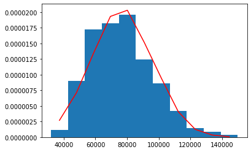

```python
fig, ax = plt.subplots()
ax.hist(ap_wage, bins=wage_bins, density=True)

pts = [(wage_bins[i]+wage_bins[i+1])/2 for i in range(0,len(wage_bins)-1)]
ax.plot(pts, counts_theory, "r-");
```

## Using the normal approximate to compute

### What percentile is an $80,000 salary?

Print with 2 digits of precision.

```python
print(f'{prob.cdf(80000):.2f}')
```

```
0.56
```

### What is the minimum salary to be in the top 10%?

Print rouding to the nearest dollar.

```python
x = prob.ppf(0.9)
```

```python
print(round(x))
```

```
102122.0
```